# Notebook #10: Ley de los Grandes Números y Teorema del Límite Central

## Introducción

Este notebook tiene como objetivo demostrar, a través de simulaciones, dos conceptos fundamentales de la probabilidad y estadística:

- La **Ley de los Grandes Números (LLN)**, que establece que conforme realizamos más repeticiones de un experimento aleatorio, el promedio de los resultados tiende a acercarse al valor esperado (convergencia en probabilidad). También se abordará cómo la desviación estándar de la media muestral disminuye a medida que el tamaño de la muestra aumenta.
- El **Teorema del Límite Central (CLT)**, que indica que, para una muestra suficientemente grande, la distribución de las medias muestrales de una variable aleatoria se aproxima a una distribución normal (convergencia en distribución), sin importar la distribución original de la variable.

## Ley de los Grandes Números (LLN)

La **Ley de los Grandes Números** establece que, a medida que el número de repeticiones o el tamaño de la muestra aumenta, el promedio de los resultados obtenidos se acerca al valor esperado teórico de la variable aleatoria.

### Fórmula de Convergencia en Probabilidad

Si $X_1, X_2, \dots, X_n$ son variables aleatorias independientes e idénticamente distribuidas (iid) con esperanza matemática $\mu$, la **Ley de los Grandes Números** en términos de **convergencia en probabilidad** establece que el promedio muestral $\overline{X}_n$ converge al valor esperado $\mu$ a medida que $n \to \infty$:

$$\overline{X}_n = \frac{1}{n} \sum_{i=1}^{n} X_i \xrightarrow{p} \mu
\quad \text{cuando} \quad n \to \infty$$

donde $\xrightarrow{p}$ denota convergencia en probabilidad.

Adicionalmente, a medida que el tamaño de la muestra aumenta, la desviación estándar de la media muestral disminuye según la siguiente fórmula:

$$\text{Desviación estándar de la media} = \frac{\sigma}{\sqrt{n}}$$

Esto significa que, a mayor tamaño muestral, la media muestral se aproxima cada vez más al valor esperado, y la variabilidad de la media disminuye.

## Teorema del Límite Central (CLT)

El **Teorema del Límite Central** afirma que, independientemente de la distribución original de una variable aleatoria, la distribución de las medias muestrales de muestras grandes sigue una distribución normal.

### Fórmula de Convergencia en Distribución

Si $X_1, X_2, \dots, X_n$ son variables aleatorias independientes e idénticamente distribuidas con media $\mu$ y desviación estándar $\sigma$, el **Teorema del Límite Central** establece que la media muestral $\overline{X}_n$ converge en distribución a una normal estándar cuando $n$ es suficientemente grande:

$$\frac{\overline{X}_n - \mu}{\frac{\sigma}{\sqrt{n}}} \xrightarrow{d}
N(0, 1) \quad \text{cuando} \quad n \to \infty$$

donde $\xrightarrow{d}$ denota convergencia en distribución y $N(0,1)$ representa la distribución normal estándar.

## Simulación

Imagina que tenemos una variable $X$ que sigue una **distribución uniforme** en la población, es decir, todos los valores entre un mínimo y un máximo tienen la misma probabilidad de ocurrir.

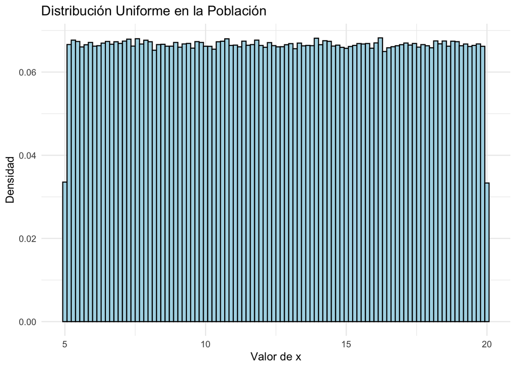

Como es común en las ciencias empíricas, no siempre tenemos acceso a toda la población, por lo que usalmente trabajamos con **muestras** de la población.

**¿Qué pasaría si quisiéramos estimar el promedio de esta variable en la población, pero usando solo los datoa contenidos en UNA muestra?**

Los teoremas de convergencia (LGN y TLC) nos indican que la respuesta depende del tamaño de la muestra que usemos. Por tanto, usando simulaciones vamos a evaluar tres tamaños de muestra:

- **$n = 30$**: una muestra pequeña.
- **$n = 100$**: una muestra de tamaño moderado.
- **$n = 500$**: una muestra más grande.

### Función para Simulación

Creaos una funció que implementa una simulación del **Teorema del Límite Central**. La función toma como parámetros el tamaño de la muestra $n$, el número de repeticiones $n_{\text{experimentos}}$, y la población de donde se extraen las muestras.

La función calcula las siguientes cantidades:

- **Media muestral**: promedio de las medias obtenidas en cada experimento.
- **Desviación estándar muestral**: desviación estándar de las medias obtenidas.
- **Media teórica** $\mu$: valor teórico de la media de la población.
- **Desviación estándar teórica** $\sigma / \sqrt{n}$: desviación estándar teórica de las medias muestrales.

La función también genera un gráfico con la distribución de las medias muestrales.

```r
# Cargamos librerías
library(tidyverse)

# Función de simulación del CLT
simulacion_clt <- function(n_muestra, n_experimentos, poblacion_data) {
  resultados_medias <- numeric(n_experimentos)

  # Realizamos la simulación de las muestras y sus medias
  for (i in 1:n_experimentos) {
    muestra <- sample_n(poblacion_data, size = n_muestra)  # Tomar muestra aleatoria
    resultados_medias[i] <- mean(muestra$value)  # Calcular la media de la muestra
  }

  # Calcular la media y desviación estándar de las medias muestrales
  media_muestral_observada <- mean(resultados_medias)
  sd_muestral_observada <- sd(resultados_medias)

  # Comparar con valores teóricos
  media_teorica <- mean(poblacion_data$value)
  sd_teorica <- sd(poblacion_data$value) / sqrt(n_muestra)

  # Graficar distribución de medias muestrales
  plot <- tibble(value = resultados_medias) %>%
    ggplot(aes(x = value)) +
    geom_histogram(aes(y = ..density..), bins = 100, fill = "lightblue", color = "black") +
    labs(x = "Media Muestral", y = "Densidad") +
    xlim(5, 20) + ylim(0, 2) +
    theme_bw()

  # Devolver un resumen de los resultados
  list(n = n_muestra, grafico = plot,
    media_muestral_observada = media_muestral_observada,
    media_teorica = media_teorica,
    sd_muestral_observada = sd_muestral_observada,
    sd_teorica = sd_teorica)

}
```

### Implementación de la Simulación

```
## [[1]]
## [[1]]$n
## [1] 30
##
## [[1]]$grafico
```

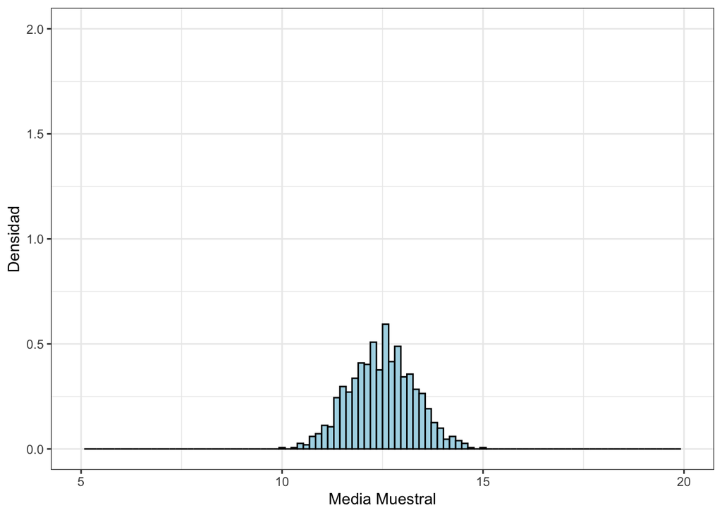

```
##
## [[1]]$media_muestral_observada
## [1] 12.49083
##
## [[1]]$media_teorica
## [1] 12.49293
##
## [[1]]$sd_muestral_observada
## [1] 0.8034303
##
## [[1]]$sd_teorica
## [1] 0.7909428
##
##
## [[2]]
## [[2]]$n
## [1] 100
##
## [[2]]$grafico
```

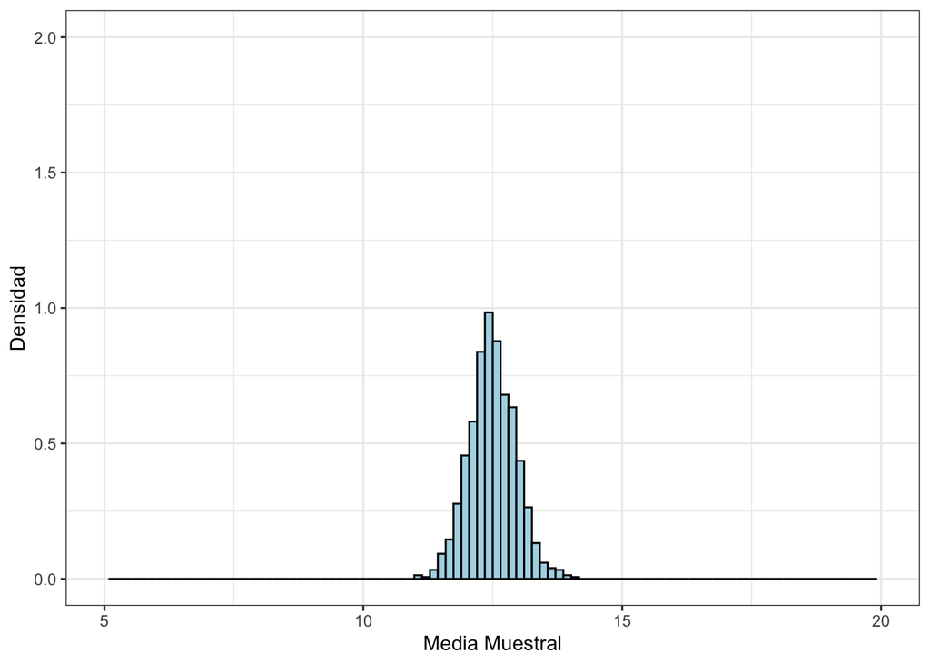

```
##
## [[2]]$media_muestral_observada
## [1] 12.49796
##
## [[2]]$media_teorica
## [1] 12.49293
##
## [[2]]$sd_muestral_observada
## [1] 0.4476332
##
## [[2]]$sd_teorica
## [1] 0.4332172
##
##
## [[3]]
## [[3]]$n
## [1] 500
##
## [[3]]$grafico
```

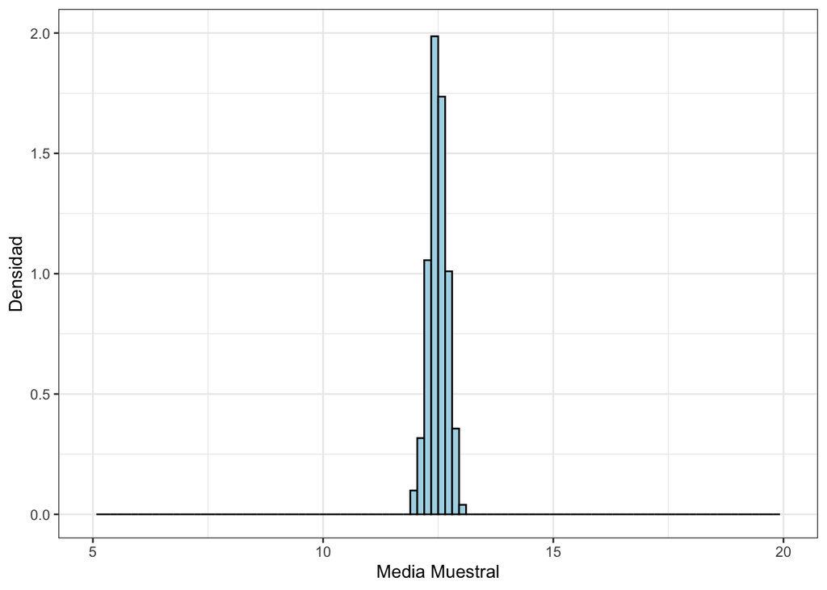

```
##
## [[3]]$media_muestral_observada
## [1] 12.49383
##
## [[3]]$media_teorica
## [1] 12.49293
##
## [[3]]$sd_muestral_observada
## [1] 0.1920697
##
## [[3]]$sd_teorica
## [1] 0.1937406
```

```r
# Generamos la población (distribución uniforme entre 5 y 20)
set.seed(123)
N <- 1000000
poblacion_data <- tibble(value = runif(N, min = 5, max = 20))

# Parámetros de simulación
n_experimentos <- 1000

# Simulación para n = 30, 100, 500

# Lista de tamaños de muestra
n_muestras <- c(30, 100, 500)

map(n_muestras, ~ simulacion_clt(.x, n_experimentos, poblacion_data))
```